# Lab 4

Author

Maria Oljaca

#### Objective: examine the association between weekly average dew point and wind speed in four regions of the US and by elevation.

### **1. Read in the data**

```r
library(tidyverse)
library(data.table)
library(cowplot)
library(magrittr)
library(ggplot2)

if (!file.exists("met_all.gz"))
  download.file(
    url = "https://raw.githubusercontent.com/USCbiostats/data-science-data/master/02_met/met_all.gz",
    destfile = "met_all.gz",
    method   = "libcurl",
    timeout  = 60
    )
met <- data.table::fread("met_all.gz")
```

### **2. Prepare the data**

```r
met <- met[temp>-17]
met2 <- met[order(temp)]
head(met2)
```

```
   USAFID  WBAN year month day hour min    lat      lon elev wind.dir
1: 726764 94163 2019     8  27   11  50 44.683 -111.116 2025       NA
2: 726764 94163 2019     8  27   12  10 44.683 -111.116 2025       NA
3: 726764 94163 2019     8  27   12  30 44.683 -111.116 2025       NA
4: 726764 94163 2019     8  27   12  50 44.683 -111.116 2025       NA
5: 720411   137 2019     8  18   12  35 36.422 -105.290 2554       NA
6: 726764 94163 2019     8  26   12  30 44.683 -111.116 2025       NA
   wind.dir.qc wind.type.code wind.sp wind.sp.qc ceiling.ht ceiling.ht.qc
1:           9              C       0          5      22000             5
2:           9              C       0          5      22000             5
3:           9              C       0          5      22000             5
4:           9              C       0          5      22000             5
5:           9              C       0          5      22000             5
6:           9              C       0          5      22000             5
   ceiling.ht.method sky.cond vis.dist vis.dist.qc vis.var vis.var.qc temp
1:                 9        N    16093           5       N          5 -3.0
2:                 9        N    16093           5       N          5 -3.0
3:                 9        N    16093           5       N          5 -3.0
4:                 9        N    16093           5       N          5 -3.0
5:                 9        N    16093           5       N          5 -2.4
6:                 9        N    16093           5       N          5 -2.0
   temp.qc dew.point dew.point.qc atm.press atm.press.qc       rh
1:       C      -5.0            C        NA            9 86.26537
2:       5      -4.0            5        NA            9 92.91083
3:       5      -4.0            5        NA            9 92.91083
4:       C      -4.0            C        NA            9 92.91083
5:       5      -3.7            5        NA            9 90.91475
6:       5      -3.0            5        NA            9 92.96690
```

```r
summary(met$dew.point)
```

```
   Min. 1st Qu.  Median    Mean 3rd Qu.    Max.    NA's
 -37.20   13.80   18.10   17.02   21.70   36.00    6287
```

```r
summary(met$wind.sp)
```

```
   Min. 1st Qu.  Median    Mean 3rd Qu.    Max.    NA's
   0.00    0.00    2.10    2.46    3.60   36.00   31743
```

```r
summary(met$elev)
```

```
   Min. 1st Qu.  Median    Mean 3rd Qu.    Max.
  -13.0   101.0   252.0   415.1   400.0  9999.0
```

```r
met[met$elev==9999.0] <- NA
summary(met$elev)
```

```
   Min. 1st Qu.  Median    Mean 3rd Qu.    Max.    NA's
  -13.0   101.0   252.0   414.3   400.0  4113.0     182
```

```r
met = mutate(met, date = as.Date(paste(year, month, day, sep = "-")))
met = mutate(met, week = week(date))
met = filter(met, week < 33 & day < 8)
```

```r
met_avg <- met[,.(
  temp     = mean(temp,na.rm=TRUE),
  rh       = mean(rh,na.rm=TRUE),
  wind.sp  = mean(wind.sp,na.rm=TRUE),
  dew.point = mean(dew.point, na.rm=TRUE),
  vis.dist = mean(vis.dist,na.rm=TRUE),
  lat      = mean(lat),
  lon      = mean(lon),
  elev     = mean(elev,na.rm=TRUE)
), by=c("USAFID")]
```

```r
met_avg = mutate(met_avg, region = ifelse(lon > -98 & lat > 39.71, "NE",
                                         ifelse(lon > -98 & lat < 39.71, "SE",
                                                ifelse(lon < -98 & lat > 39.71, "NW", "SW"))))
met_avg = mutate(met_avg, elev_cat = ifelse(elev > 252, "high", "low"))
```

### **3. Use `geom_violin` to examine the wind speed and dew point by region**

**Wind speed graph:** The NW and SW regions have a higher median average wind speed (approx 3.0 m/s) than the NE and SE regions (approx 1.25-2.0 m/s). The NW and SW regions appear to have relatively symmetrical distributions of average wind speed, while the SE region has a positively skewed distribution and the NE region has several outliers at high wind speeds.

**Dew point graph:** The SE region stands out as having the highest median average dew point (approx 22 degrees C), followed by the NE region (approx 17 degrees C), and then the NW and SW regions (somewhere between 10-15 degrees C). The NW and SW regions have notably more variability in their average dew points than the NE and SE regions, which have narrower, more symmetric distributions. Both the NW and SW regions have a negative skew in their distributions of average dew points.Notably, the distribution of average dew points in the NW region appears to be bi-modal.

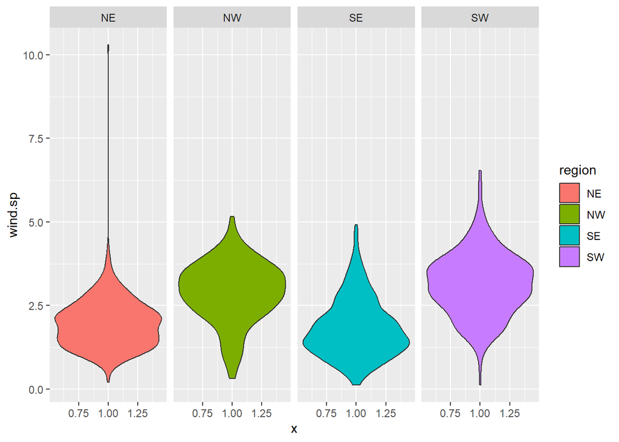

```r
met_avg[!is.na(region)] %>%
  ggplot()+
  geom_violin(mapping=aes(x=1, y=wind.sp, fill=region))+
  facet_wrap(~ region, nrow = 1)
```

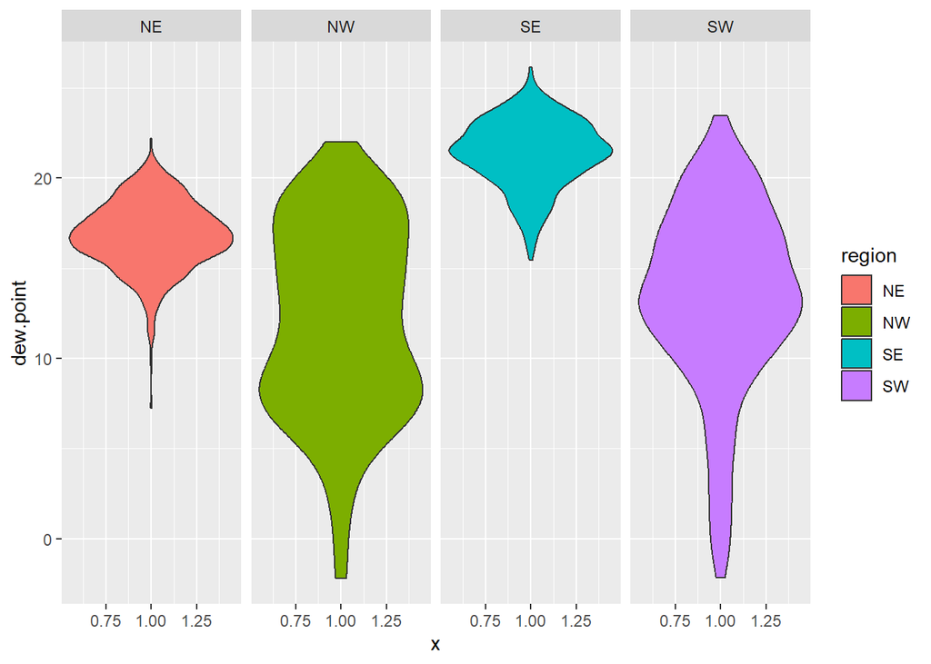

```r
met_avg[!is.na(region)] %>%
  ggplot()+
  geom_violin(mapping=aes(x=1, y=dew.point, fill=region))+
  facet_wrap(~ region, nrow = 1)
```

### **4. Use `geom_jitter` with `stat_smooth` to examine the association between dew point and wind speed by region**

For the SW region, there appears to be a very slight negative association between dew point and wind speed.

For the NE, NW, and SE regions, there appear to be positive associations of varying strengths between dew point and wind speed. The strongest positive association appears to be in the SE region.

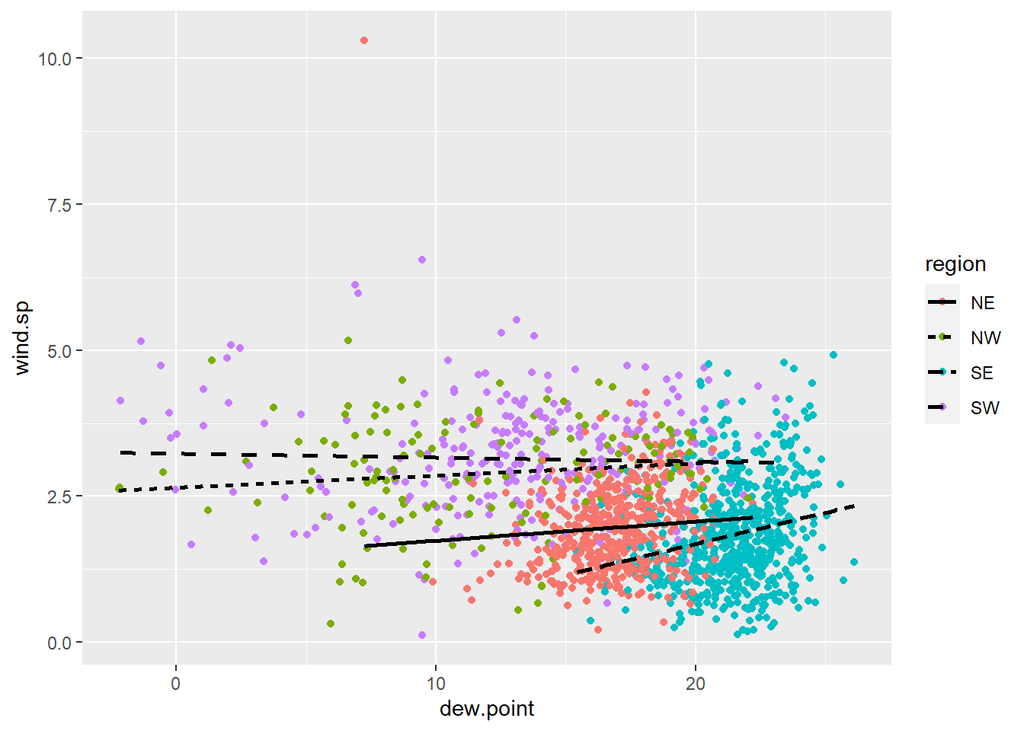

```r
met_avg[!is.na(region)] %>%
  ggplot(mapping = aes(x=dew.point, y=wind.sp, color=region, linetype=region))+
  geom_jitter()+
  stat_smooth(method = lm, se=FALSE, col="black")
```

### **5. Use `geom_bar` to create barplots of the weather stations by elevation category colored by region**

Most of the weather stations at high elevations are coming from the NE region (approx 250), followed by the SW region (approx 200). The NW and SE regions have the least number of weather stations at high elevations (approx 150).

The highest frequency by far of weather stations at low elevations are in the SE region (approx 500), followed by the NE region (approx 225) and then the SW region (approx 80), with very few weather stations at low elevations in the NW region (approx 15)..

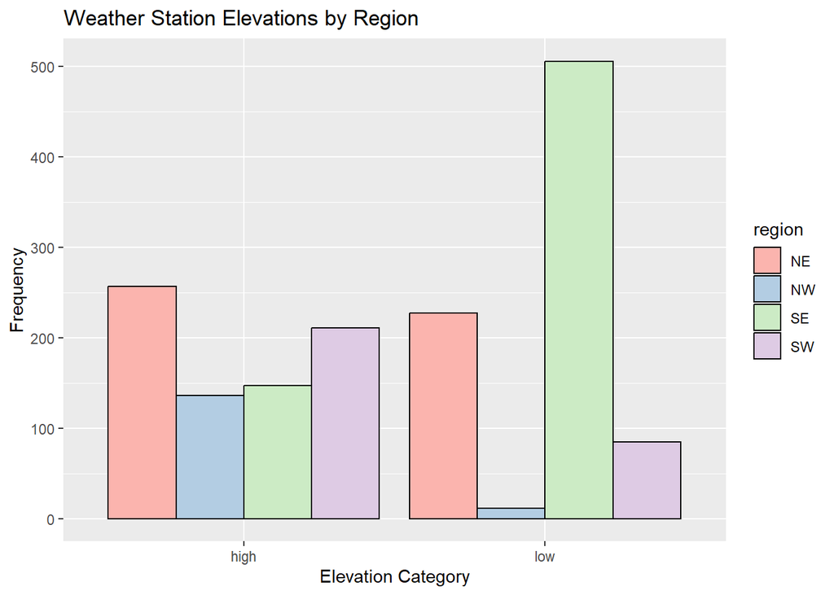

```r
met_avg[!is.na(region)] %>%
  ggplot(mapping = aes(x = elev_cat, fill=region))+
  geom_bar(color="black", position="dodge")+
  scale_fill_brewer(palette = "Pastel1")+
  labs(title = "Weather Station Elevations by Region")+
  labs(x = "Elevation Category", y="Frequency")
```

### **6. Use `stat_summary` to examine mean dew point and wind speed by region with standard deviation error bars**

Dew point graph:

Mean dew point in order from highest to lowest: SE, NE, SW, NW. The NE and SE regions have very narrow error bars, indicating low variability around the mean dew point. The NW region has the widest error bars, indicating highest variability around the mean dew point of all the regions.

Wind speed graph:

```
No summary function supplied, defaulting to `mean_se()`
```

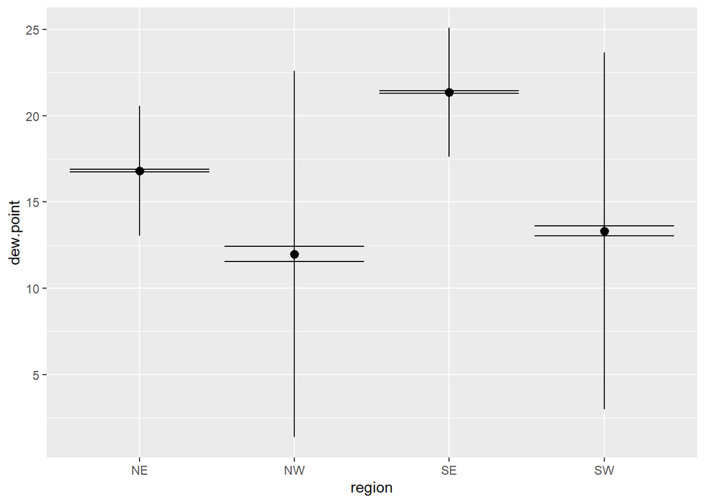

```r
met_avg[!is.na(region)] %>%
  ggplot() +
    stat_summary(mapping = aes(x = region, y = dew.point),
    fun.data="mean_sdl") +
  stat_summary(mapping = aes(x = region, y = dew.point), geom = "errorbar")
```

```
No summary function supplied, defaulting to `mean_se()`
```

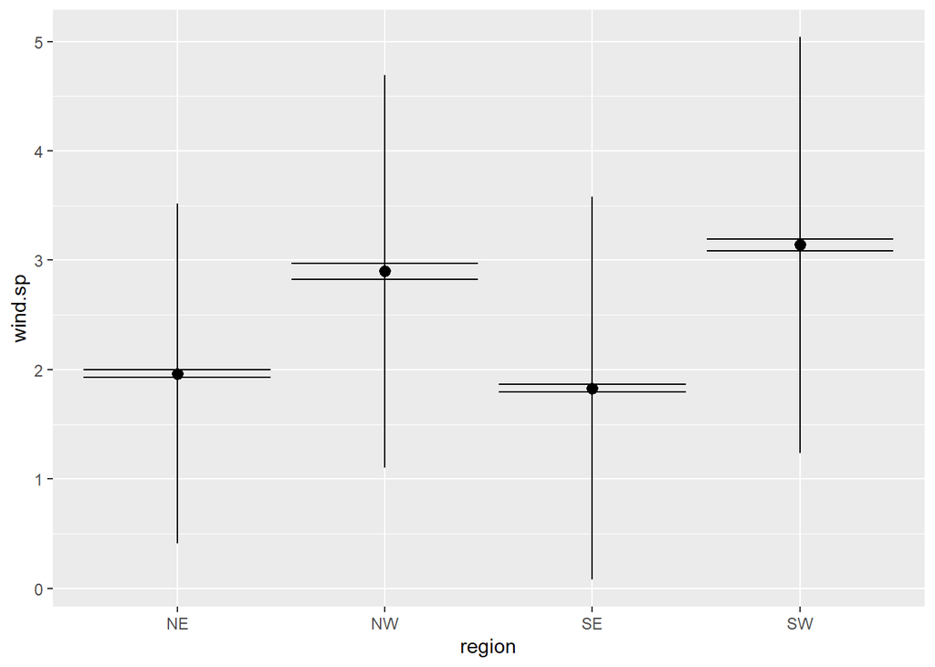

```r
met_avg[!is.na(region)] %>%
  ggplot() +
    stat_summary(mapping = aes(x = region, y = wind.sp),
    fun.data="mean_sdl") +
  stat_summary(mapping = aes(x = region, y = wind.sp), geom = "errorbar")
```

### **7. Make a map showing the spatial trend in relative humidity in the US**

In general, relative humidity is higher on the east coast than on the west coast.

```r
library(leaflet)
met_avg2 <- met[,.(rh = mean(rh,na.rm=TRUE), lat = mean(lat), lon = mean(lon)),  by=c("USAFID")]
met_avg2 <- met_avg2[!is.na(rh)]
rh.pal <- colorNumeric(c('lightblue','lavender','magenta'), domain=met_avg2$temp)
rh.pal
```

[output not shown]

```r
rhmap <- leaflet(met_avg2) %>%
  addProviderTiles('CartoDB.Positron') %>%
  addCircles(
    lat = ~lat, lng=~lon,
    label = ~paste0(round(rh,2)), color = ~ rh.pal(rh),
    opacity = 1, fillOpacity = 1, radius = 500
    ) %>%
  addLegend('bottomleft', pal=rh.pal, values=met_avg2$rh,
          title='Relative Humidity', opacity=1)
rhmap
```

[interactive chart not shown]

### **8. Use a ggplot extension**

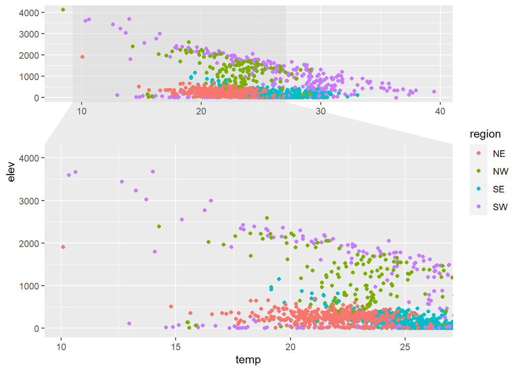

```r
library(ggforce)
ggplot(met_avg, aes(temp, elev, colour = region)) +
  geom_point() +
  facet_zoom(x = region == "NE")
```